# Introduction do Data Visualization with ggplot2

by Edneide Ramalho

18 Agosto, 2021

# 1 Drawing your first plot

To get a first feel for `ggplot2`, let’s try to run some basic `ggplot2` commands. The `mtcars` dataset contains information on 32 cars from a 1973 issue of Motor Trend magazine. This dataset is small, intuitive, and contains a variety of continuous and categorical variables.

- Load the `ggplot2` package using [**`library()`**](http://www.rdocumentation.org/packages/base/functions/library).
- Use [**`str()`**](http://www.rdocumentation.org/packages/utils/functions/str) to explore the structure of the `mtcars` dataset.
- Hit *Submit Answer*. This will execute the example code on the right. See if you can understand what `ggplot` does with the data.

```r
# Load the ggplot2 package
library(ggplot2)

# Explore the mtcars data frame with str()
str(mtcars)
```

```
## 'data.frame':    32 obs. of  11 variables:
##  $ mpg : num  21 21 22.8 21.4 18.7 18.1 14.3 24.4 22.8 19.2 ...
##  $ cyl : num  6 6 4 6 8 6 8 4 4 6 ...
##  $ disp: num  160 160 108 258 360 ...
##  $ hp  : num  110 110 93 110 175 105 245 62 95 123 ...
##  $ drat: num  3.9 3.9 3.85 3.08 3.15 2.76 3.21 3.69 3.92 3.92 ...
##  $ wt  : num  2.62 2.88 2.32 3.21 3.44 ...
##  $ qsec: num  16.5 17 18.6 19.4 17 ...
##  $ vs  : num  0 0 1 1 0 1 0 1 1 1 ...
##  $ am  : num  1 1 1 0 0 0 0 0 0 0 ...
##  $ gear: num  4 4 4 3 3 3 3 4 4 4 ...
##  $ carb: num  4 4 1 1 2 1 4 2 2 4 ...
```

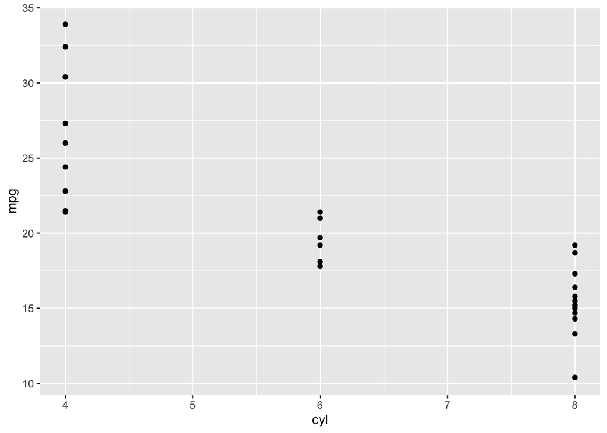

```r
# Execute the following command
ggplot(mtcars, aes(cyl, mpg)) +
  geom_point()
```

## 1.1 **Data columns types affect plot types**

The plot from the previous exercise wasn’t really satisfying. Although `cyl` (the number of cylinders) is categorical, you probably noticed that it is classified as numeric in `mtcars`. This is really misleading because the representation in the plot doesn’t match the actual data type. You’ll have to explicitly tell `ggplot2` that `cyl` is a categorical variable.

- Change the [**`ggplot()`**](http://www.rdocumentation.org/packages/ggplot2/functions/ggplot) command by wrapping [**`factor()`**](http://www.rdocumentation.org/packages/base/functions/factor) around `cyl`.
- Hit *Submit Answer* and see if the resulting plot is better this time.

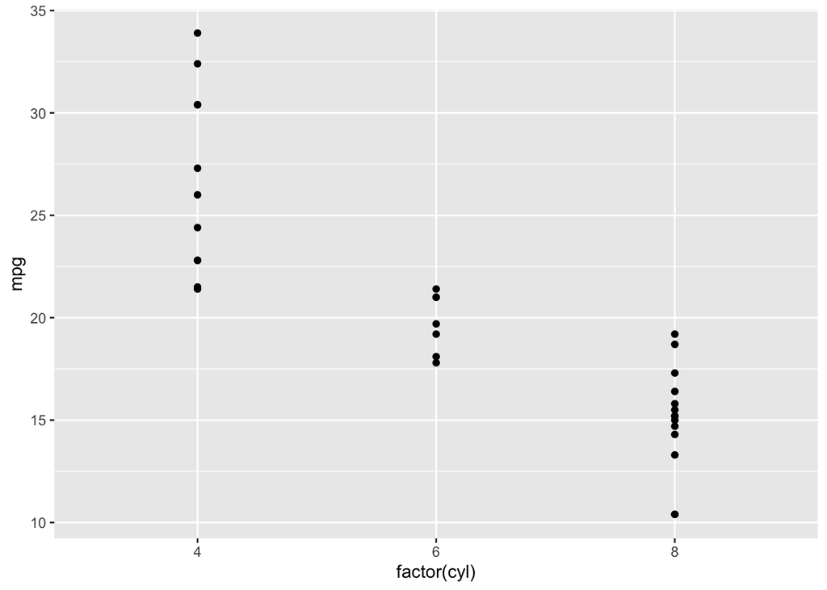

```r
# Load the ggplot2 package
library(ggplot2)

# Change the command below so that cyl is treated as factor
ggplot(mtcars, aes(factor(cyl), mpg)) +
  geom_point()
```

# 2 **Mapping data columns to aesthetics**

Let’s dive a little deeper into the three main topics in this course: The data, aesthetics, and geom layers. We’ll get to making pretty plots in the last chapter with the themes layer.

We’ll continue working on the 32 cars in the `mtcars` data frame.

Consider how the examples and concepts we discuss throughout these courses apply to your own data-sets!

- Add a color aesthetic mapped to the displacement of the car engine: inside [**`aes()`**](http://www.rdocumentation.org/packages/ggplot2/functions/aes), add a `color` argument equal to `disp`.

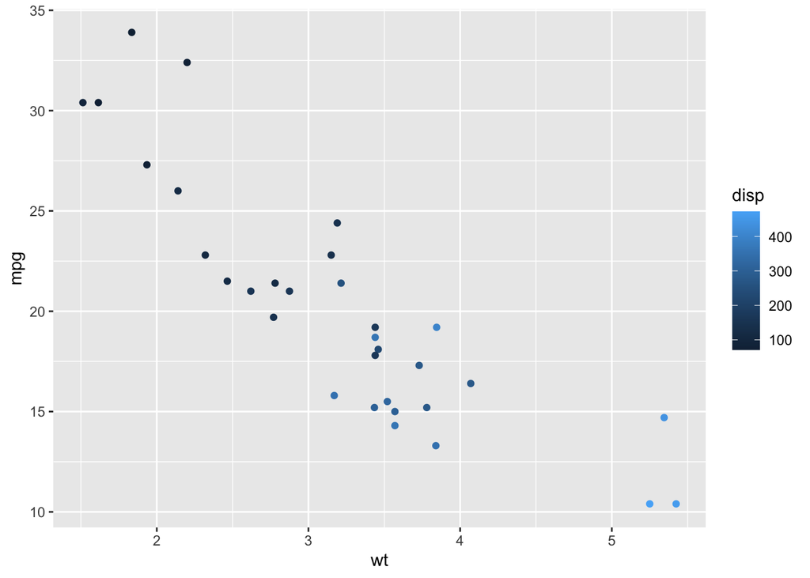

```r
# Edit to add a color aesthetic mapped to disp
ggplot(mtcars, aes(wt, mpg, color = disp))+
  geom_point()
```

- This time, map `disp` to the `size` aesthetic.

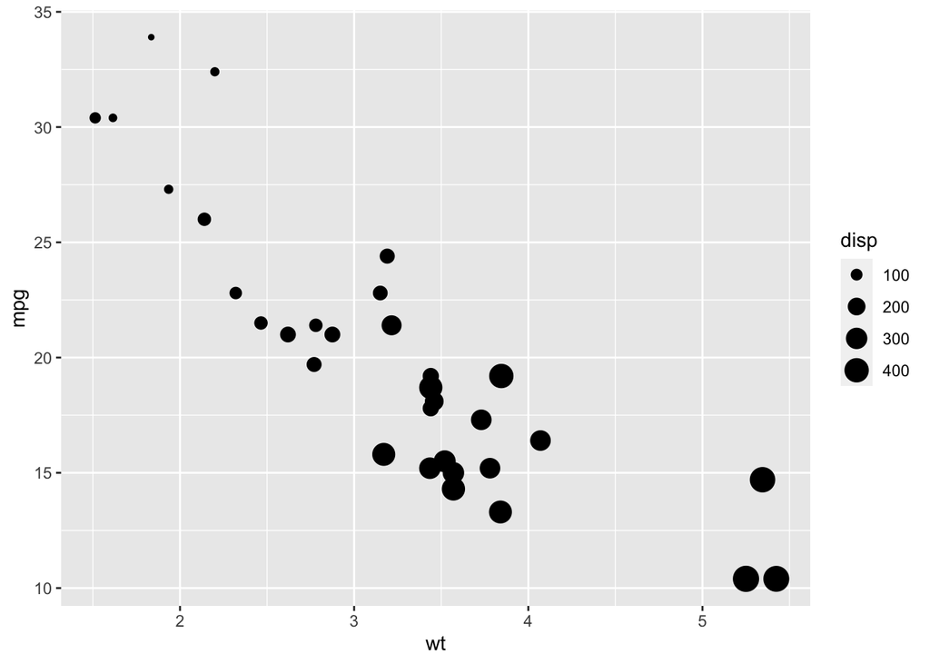

```r
# Change the color aesthetic to a size aesthetic
ggplot(mtcars, aes(wt, mpg, size = disp)) +
  geom_point()
```

## 2.1 Understanding variables

In the previous exercise you saw that `disp` can be mapped onto a color gradient or onto a continuous size scale.

Another argument of [**`aes()`**](http://www.rdocumentation.org/packages/ggplot2/functions/aes) is the `shape` of the points. There are a finite number of shapes which [**`ggplot()`**](http://www.rdocumentation.org/packages/ggplot2/functions/ggplot) can automatically assign to the points. However, if you try this command in the console to the right:

```
ggplot(mtcars, aes(wt, mpg, shape = disp)) +
  geom_point()
```